# Linear Models and Generalized Linear Models in R, using `lm()` and `glm()`

First, we are going to discuss how to do a linear regression in R. We are going to focus on the use of linear regression to predict a quantitative response. For example, we might want to learn how to predict the median value of a home, our repsonse variable, based on several possible explanatory variables, such as property-tax, distance to employment centres, number of rooms, etc.

### What can a linear model tell us?

1. Is there a relationship between our response and explanatory variables?
2. How strong is the relationship our response and explanatory variables?
3. Which explanatory variables contribute to our response variable?
4. How accurately can we estimate the effect of each explanatory variable on the response variable?
5. How accurately can we predict future outcomes
6. Is the relationship linear?
7. Is there synergy among the explanatory variables?

### Explore the data

```r
library(MASS)
help(Boston)
str(Boston)
```

```
'data.frame':   506 obs. of  14 variables:
 $ crim   : num  0.00632 0.02731 0.02729 0.03237 0.06905 ...
 $ zn     : num  18 0 0 0 0 0 12.5 12.5 12.5 12.5 ...
 $ indus  : num  2.31 7.07 7.07 2.18 2.18 2.18 7.87 7.87 7.87 7.87 ...
 $ chas   : int  0 0 0 0 0 0 0 0 0 0 ...
 $ nox    : num  0.538 0.469 0.469 0.458 0.458 0.458 0.524 0.524 0.524 0.524 ...
 $ rm     : num  6.58 6.42 7.18 7 7.15 ...
 $ age    : num  65.2 78.9 61.1 45.8 54.2 58.7 66.6 96.1 100 85.9 ...
 $ dis    : num  4.09 4.97 4.97 6.06 6.06 ...
 $ rad    : int  1 2 2 3 3 3 5 5 5 5 ...
 $ tax    : num  296 242 242 222 222 222 311 311 311 311 ...
 $ ptratio: num  15.3 17.8 17.8 18.7 18.7 18.7 15.2 15.2 15.2 15.2 ...
 $ black  : num  397 397 393 395 397 ...
 $ lstat  : num  4.98 9.14 4.03 2.94 5.33 ...
 $ medv   : num  24 21.6 34.7 33.4 36.2 28.7 22.9 27.1 16.5 18.9 ...
```

Let’s start by exploring the relationship between the median value of a home (`medv`), our repsonse variable, and distance to employment centres (`dis`), an explanatory variable.

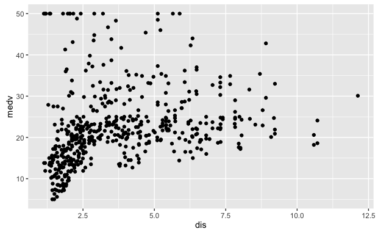

```r
library(ggplot2)
qplot(y = medv, x = dis, data = Boston)
```

### Fit a model

There looks as though there may be some relationship, so let’s try and fit a model to assess this:

```r
medv_vs_dis <- lm(medv ~ dis, data = Boston)
```

### Interpreting and working with model outputs

To view the results of the model, tradionally we would use the `summary()` command:

```r
summary(medv_vs_dis)
```

```
Call:
lm(formula = medv ~ dis, data = Boston)

Residuals:
    Min      1Q  Median      3Q     Max
-15.016  -5.556  -1.865   2.288  30.377

Coefficients:
            Estimate Std. Error t value Pr(>|t|)
(Intercept)  18.3901     0.8174  22.499  < 2e-16 ***
dis           1.0916     0.1884   5.795 1.21e-08 ***
---
Signif. codes:  0 ‘***’ 0.001 ‘**’ 0.01 ‘*’ 0.05 ‘.’ 0.1 ‘ ’ 1

Residual standard error: 8.914 on 504 degrees of freedom
Multiple R-squared:  0.06246,   Adjusted R-squared:  0.0606
F-statistic: 33.58 on 1 and 504 DF,  p-value: 1.207e-08
```

Which is great, we can see all the results we want, but if we want to do anything with these results, it can be quite a bit of work. An alternative is to use the 3 functions in the `broom` package to get these results into a tidy data frame that is easy to work with. The first function we will look at is tidy, it gives us the model’s statistical findings, such as the coefficients:

```r
library(broom)
tidy(medv_vs_dis)
```

```
         term  estimate std.error statistic      p.value
1 (Intercept) 18.390088 0.8173887 22.498584 4.008955e-78
2         dis  1.091613 0.1883784  5.794788 1.206612e-08
```

We can see that both the intercept and the slope of the line (the coefficient for distance to employment centre) is significant.

The next function from the `broom` package that is very useful is `glance()`. This function always returns a one row data frame with model-level statistics (e.g., Adjusted R-squared, AIC, BIC).

```r
glance(medv_vs_dis)
```

```
   r.squared adj.r.squared    sigma statistic      p.value df    logLik      AIC
1 0.06246437    0.06060418 8.914057  33.57957 1.206612e-08  2 -1823.921 3653.843
       BIC deviance df.residual
1 3666.522 40048.05         504
```

We can see that even though we found that there is a significant relationship between median home value and distance to employment centre, the Adjusted R-squared indicates that our linear model does not explain much of the variation in the data. We may be missing some critical variables in our model, or that the relationship between median home value and distance to employment centre may not be linear.

To further assess this, we can examine the distribution of the residuals. To access the residuals, we can use the `augment()` function from the `broom` package:

```r
obs_stats <- augment(medv_vs_dis)
head(obs_stats)
```

```
  medv    dis  .fitted   .se.fit    .resid        .hat   .sigma      .cooksd
1 24.0 4.0900 22.85479 0.4001546  1.145214 0.002015138 8.922767 1.669743e-05
2 21.6 4.9671 23.81224 0.4536350 -2.212239 0.002589777 8.922367 8.016746e-05
3 34.7 4.9671 23.81224 0.4536350 10.887761 0.002589777 8.909663 1.941829e-03
4 33.4 6.0622 25.00766 0.5826120  8.392335 0.004271771 8.915030 1.909463e-03
5 36.2 6.0622 25.00766 0.5826120 11.192335 0.004271771 8.908887 3.396151e-03
6 28.7 6.0622 25.00766 0.5826120  3.692335 0.004271771 8.921388 3.696135e-04
  .std.resid
1  0.1286025
2 -0.2484962
3  1.2229994
4  0.9434893
5  1.2582730
6  0.4151025
```

*note - we wrapped augment in head so that we didn’t print out all 506 rows of the dataframe*

To look at the distribtion of the residuals, we’ll use `ggplot`’s `geom_density()` function:

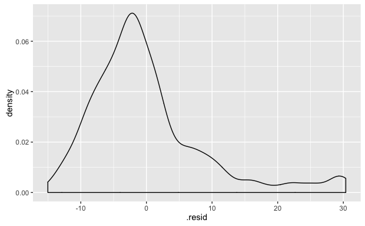

```r
ggplot(obs_stats, aes(.resid)) + geom_density()
```

Hmm… the distribution of the residuals looks almost normal, but has a weirdly shaped tail… Let’s investigate the homoscedasticity to assess whether the variance around the regression line is the same for all values of the explanatory variable, distance to employment centre:

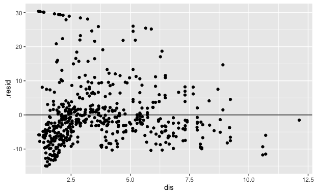

```r
ggplot(obs_stats, aes(x = dis, y = .resid)) + geom_point() + geom_hline(yintercept=0)
```

We can see that indeed, the variance is not the same for all values of the explanatory variable, distance to employment centre. Thus, we might want to use an alternative method for linerar regressison, such as robust regression, or transform the distance variable in a way such that the variance is more evenly distributed for all values of the explanatory variable.

### Fitting a model with multiple explanatory variables

The Boston dataset we are working with has many different explanatory variables, and as such we can fit a model with multiple explanatory variables, and even mutliple interacting terms. Below is the syntax for fitting a model with multiple explanatory variables but no interacting terms:

```r
medv_vs_three_vars <- lm(medv ~ dis + lstat + ptratio + age, data = Boston)
tidy(medv_vs_three_vars)
```

```
         term      estimate  std.error    statistic      p.value
1 (Intercept) 58.9540965762 2.64209035  22.31342939 4.289454e-77
2         dis -0.7505813389 0.17986655  -4.17299013 3.544330e-05
3       lstat -0.9261590795 0.04588340 -20.18505940 9.581002e-67
4     ptratio -1.1848916651 0.12489044  -9.48744892 9.556703e-20
5         age  0.0002005881 0.01461982   0.01372028 9.890586e-01
```

```r
glance(medv_vs_three_vars)
```

```
  r.squared adj.r.squared    sigma statistic       p.value df    logLik      AIC
1 0.6289119     0.6259492 5.624921   212.271 2.260109e-106  5 -1589.437 3190.874
       BIC deviance df.residual
1 3216.234 15851.51         501
```

We can see that there is a significant relationship between median home value and three of the explanatory variables dis (distnance to employment centres), lstat (lower status of the population) and ptratio (pupil-teacher ratio by town), but not age (proportion of owner-occupied units built prior to 1940).

We also see that our Adjusted R-squared is much higher, indicating that this model explains much more of the variance in the data.

```r
glance(medv_vs_three_vars)
```

```
  r.squared adj.r.squared    sigma statistic       p.value df    logLik      AIC
1 0.6289119     0.6259492 5.624921   212.271 2.260109e-106  5 -1589.437 3190.874
       BIC deviance df.residual
1 3216.234 15851.51         501
```

If we want to run the linear regression against all possible explanatory variables in the dataset, we would use `.` to represent “all”:

```r
medv_vs_all <- lm(medv ~ ., data = Boston)
tidy(medv_vs_all)
```

```
          term      estimate   std.error    statistic      p.value
1  (Intercept)  3.645949e+01 5.103458811   7.14407419 3.283438e-12
2         crim -1.080114e-01 0.032864994  -3.28651687 1.086810e-03
3           zn  4.642046e-02 0.013727462   3.38157628 7.781097e-04
4        indus  2.055863e-02 0.061495689   0.33431004 7.382881e-01
5         chas  2.686734e+00 0.861579756   3.11838086 1.925030e-03
6          nox -1.776661e+01 3.819743707  -4.65125741 4.245644e-06
7           rm  3.809865e+00 0.417925254   9.11614020 1.979441e-18
8          age  6.922246e-04 0.013209782   0.05240243 9.582293e-01
9          dis -1.475567e+00 0.199454735  -7.39800360 6.013491e-13
10         rad  3.060495e-01 0.066346440   4.61289977 5.070529e-06
11         tax -1.233459e-02 0.003760536  -3.28000914 1.111637e-03
12     ptratio -9.527472e-01 0.130826756  -7.28251056 1.308835e-12
13       black  9.311683e-03 0.002685965   3.46679256 5.728592e-04
14       lstat -5.247584e-01 0.050715278 -10.34714580 7.776912e-23
```

Now we see that there is a significant relationship between median home value and all explanatory variables except for indus (proportion of non-retail business acres per town) and age (proportion of owner-occupied units built prior to 1940).

Finally, we might want to fit a model that has multiple interaction terms to indicate that we would like to model synergy between two explanatory variables. The syntax for this is as follows:

```r
medv_w_interaction <- lm(medv ~ dis + crim * lstat, data = Boston)
tidy(medv_w_interaction)
```

```
         term    estimate   std.error  statistic       p.value
1 (Intercept) 40.23827946 1.059686312  37.971878 1.481902e-149
2         dis -0.89733247 0.150988943  -5.943034  5.244818e-09
3        crim -0.52025234 0.102939799  -5.053948  6.076437e-07
4       lstat -1.09918263 0.050501594 -21.765306  2.002448e-74
5  crim:lstat  0.02020167 0.004723946   4.276439  2.274773e-05
```

You can see that when we include an interaction term, we also automatically include the individual explanatory variables within that interaction term. The model results here tell us that in addition to crim & lstat being significant on their own, they also have a combined effect.

### Generalized linear models

Linear models are great if we have a continuous response variable that is roughly normally distributed, but what about cases where that is not the case? For example, what if the response is not linear at all, for example a categorical response variable coded as 0 or 1? Well in those cases it is best to use a generalized linear model instead of a linear model. Why? Well in this specific example, if we fit a linear model, it would make predictions outside of 0 and 1, and that really wouldn’t make any sense with our data, now would it?

Let’s quickly go through an example of this with the Titanic dataset, and let’s start by looking at the titanic dataset:

```r
library(titanic)
str(titanic_train)
```

```
'data.frame':   891 obs. of  12 variables:
 $ PassengerId: int  1 2 3 4 5 6 7 8 9 10 ...
 $ Survived   : int  0 1 1 1 0 0 0 0 1 1 ...
 $ Pclass     : int  3 1 3 1 3 3 1 3 3 2 ...
 $ Name       : chr  "Braund, Mr. Owen Harris" "Cumings, Mrs. John Bradley (Florence Briggs Thayer)" "Heikkinen, Miss. Laina" "Futrelle, Mrs. Jacques Heath (Lily May Peel)" ...
 $ Sex        : chr  "male" "female" "female" "female" ...
 $ Age        : num  22 38 26 35 35 NA 54 2 27 14 ...
 $ SibSp      : int  1 1 0 1 0 0 0 3 0 1 ...
 $ Parch      : int  0 0 0 0 0 0 0 1 2 0 ...
 $ Ticket     : chr  "A/5 21171" "PC 17599" "STON/O2. 3101282" "113803" ...
 $ Fare       : num  7.25 71.28 7.92 53.1 8.05 ...
 $ Cabin      : chr  "" "C85" "" "C123" ...
 $ Embarked   : chr  "S" "C" "S" "S" ...
```

Let’s explore whether there is a relationship between surviving (response variable) and fare (how much you paid for your ticket). Let’s look at a boxplot to explore this:

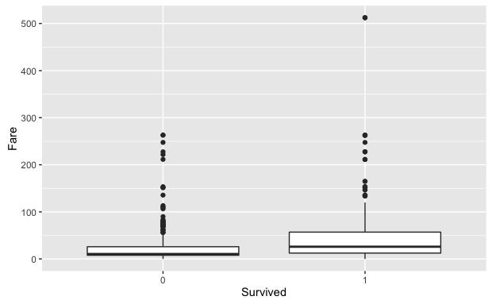

```r
titanic_train$Survived <- as.factor(titanic_train$Survived)
ggplot(titanic_train, aes(Survived, Fare)) + geom_boxplot()
```

```r
survived_vs_fare <- glm(Survived ~ Fare, data = titanic_train, family=binomial(link = "logit"))
tidy(survived_vs_fare)
```

```
         term    estimate   std.error statistic      p.value
1 (Intercept) -0.94132990 0.095129144 -9.895284 4.363702e-23
2        Fare  0.01519687 0.002231678  6.809614 9.786127e-12
```

We can see from our model that there does appear to be a significant relationship between who survived and how much they paid for their fare.

You can also use `glance()` and `augment` with `glm`’s to get the model and observation statistics, respecively.

```r
glance(survived_vs_fare)
```

```
  null.deviance df.null    logLik      AIC      BIC deviance df.residual
1      1186.655     890 -558.7846 1121.569 1131.154 1117.569         889
```

```r
head(augment(survived_vs_fare))
```

```
  Survived    Fare    .fitted    .se.fit     .resid        .hat   .sigma
1        0  7.2500 -0.8311526 0.08535672 -0.8503481 0.001539884 1.121476
2        1 71.2833  0.1419529 0.12016950  1.1177544 0.003592110 1.121210
3        1  7.9250 -0.8208947 0.08454701  1.5398468 0.001516877 1.120647
4        1 53.1000 -0.1343763 0.09086681  1.2349824 0.002054884 1.121072
5        0  8.0500 -0.8189951 0.08439916 -0.8546931 0.001512692 1.121472
6        0  8.4583 -0.8127902 0.08392088 -0.8569164 0.001499187 1.121470
       .cooksd .std.resid
1 0.0003363810 -0.8510036
2 0.0015696254  1.1197674
3 0.0017288166  1.5410160
4 0.0011800567  1.2362532
5 0.0003344647 -0.8553403
6 0.0003335330 -0.8575594
```